# Lógica y Pensamiento Científico

Repaso para el parcial

Bogdan G. Popescu

bgpopescu@tec.mx

Tecnologico de Monterrey

## Formato del examen

- Sin apuntes, individual, en clase.
- Cubre las **Sesiones 1–7**.
- Evalúa los conceptos, el vocabulario y su aplicación a casos breves.
- Las **lecturas obligatorias** de esas sesiones entran.

## Calificación

| Componente | Peso |
| --- | --- |
| Examen parcial | **30%** |
| Examen final | **30%** |
| Lectura | 20% |
| Presencia | 10% |
| Participación | 10% |

Dos exámenes, **60%** juntos — y ninguno de los dos es acumulativo.

**Lectura 20%** — se evalúa en los exámenes. **Presencia y participación 20%** — se ganan en el salón.

# Parte 1: Todas las herramientas

## Encontrar el argumento

Un **argumento** da razones para una afirmación.

| **Conclusión** | la afirmación que se defiende |
| --- | --- |
| **Premisas** | las razones que se ofrecen para ella |

Encuentren **primero** la conclusión. Todo lo demás son premisas o ruido.

## No todo argumenta

|  | Ejemplo | Por qué no es un argumento |
| --- | --- | --- |
| **Descripción** | *“Está lloviendo afuera.”* | enuncia un hecho, no defiende nada |
| **Opinión** | *“Messi es el mejor de la historia.”* | un juicio, sin razones pegadas |
| **Contradicción** | *“No, no lo es.”* | niega la afirmación, no da razón |
| **Explicación** | *“Llegué tarde — había mucho tráfico.”* | dice *por qué* pasó un hecho aceptado |

A una contradicción le falta una palabra para ser argumento: **porque.**

**La prueba para las explicaciones:** ¿la conclusión está realmente en disputa?

## Forma estándar

> “No deberíamos recortar el presupuesto militar — nuestra Marina es más chica que en 1917.”

| P1. | Nuestra Marina es más chica que en 1917. |
| --- | --- |
| P2. | *(oculta)* Menos barcos significa una fuerza militar más débil. |
| P3. | *(oculta)* Recortar el presupuesto encogería más la flota. |
| P4. | *(oculta)* No deberíamos debilitar a la fuerza militar. |
| C. | No deberíamos recortar el presupuesto militar. |

## Tres tipos de afirmación

**Una sola pregunta las separa: *¿qué zanjaría esto?***

|  | La respuesta | Ejemplo |
| --- | --- | --- |
| **Empírica** | ir y ver | “Nuestra Marina es más chica que en 1917.” |
| **Conceptual** | ponernos de acuerdo en qué significa la palabra | “‘Fuerza’ es lo que un ejército puede hacer.” |
| **Normativa** | discutir qué es lo que importa | “No deberíamos debilitar a la fuerza militar.” |

Una afirmación llena de datos puede seguir siendo **normativa.** Busquen la palabra de valor.

## El “debería” oculto

No pueden sacar un **debería** de premisas que solo dicen **es.**

- Toda conclusión normativa necesita al menos una premisa normativa.
- Si no encuentran una enunciada — está oculta.
- Nombrarla es como encuentran dónde discrepar.

## ¿Garantía o buena apuesta?

```
%%{init: {"flowchart": {"useMaxWidth": true, "htmlLabels": false, "nodeSpacing": 24, "rankSpacing": 34, "padding": 18}, "themeVariables": {"fontSize": "14px", "edgeLabelBackground": "#ffffff"}}}%%
flowchart TB
  A["UN ARGUMENTO<br/>¿qué promete?"]
  A -->|"una GARANTÍA"| D["DEDUCTIVO"]
  A -->|"una BUENA APUESTA"| I["INDUCTIVO"]
  D --> D1["el enlace<br/>VÁLIDO o INVÁLIDO"]
  I --> I1["el enlace<br/>FUERTE o DÉBIL"]
  D1 --> D2["+ premisas ciertas<br/>= SÓLIDO"]
  I1 --> I2["+ premisas ciertas<br/>= COGENTE"]
  style A fill:#1e293b,color:#f9fafb,stroke:#1e293b
  style D fill:#4a7c6f,color:#f9fafb,stroke:#4a7c6f
  style I fill:#b44527,color:#f9fafb,stroke:#b44527
  style D1 fill:#cfe0d8,color:#1e293b,stroke:#4a7c6f
  style D2 fill:#cfe0d8,color:#1e293b,stroke:#4a7c6f
  style I1 fill:#f4e4dc,color:#1e293b,stroke:#b44527
  style I2 fill:#f4e4dc,color:#1e293b,stroke:#b44527
```

## Los cuatro pasos

Cada argumento, en el mismo orden:

1. **¿Deductivo o inductivo?** *(¿una garantía o una buena apuesta?)*
2. **¿Aguanta el enlace?** *(deductivo → ¿válido? · inductivo → ¿fuerte?)*
3. **¿Son ciertas las premisas?**
4. **Veredicto en una palabra:** *sólido · cogente · o ninguno.*

## Validez no es verdad

**Los valores de verdad casi no dicen nada sobre la validez.**

| Premisas | Conclusión | Qué pueden concluir |
| --- | --- | --- |
| falsas | cualquiera | nada — puede ser válido o inválido |
| ciertas | cierta | nada — puede ser válido o inválido |
| **ciertas** | **falsa** | **inválido — garantizado** |

*“Todos los gatos son reptiles; todos los reptiles hablan francés; entonces todos los gatos hablan francés.”* — **silogismo hipotético**

Cada renglón falso — y perfectamente **válido.**

## Las cinco formas

Una regla, cinco movimientos: *“Si llueve, la calle se moja.”*

|  | El movimiento |  |
| --- | --- | --- |
| **Modus ponens** | Llovió → **la calle está mojada** | válido |
| **Modus tollens** | La calle está seca → **no llovió** | válido |
| **Silogismo hipotético** | lluvia → mojada → **resbalosa** | válido |
| **Afirmar el consecuente** | La calle está mojada → **llovió** | **trampa** |
| **Negar el antecedente** | No llovió → **la calle está seca** | **trampa** |

Las dos trampas olvidan el **tubo roto** — la calle puede mojarse sin lluvia.

## Modus ponens

**P1:** Si algo es perro, entonces es mamífero.  
**P2:** Fido es perro.  
**C:** Fido es mamífero.

**modus ponens**

Shape: **Si P, entonces Q. P. entonces Q**

**Válido** — se cumple el *si*, así que se sigue el *entonces*.

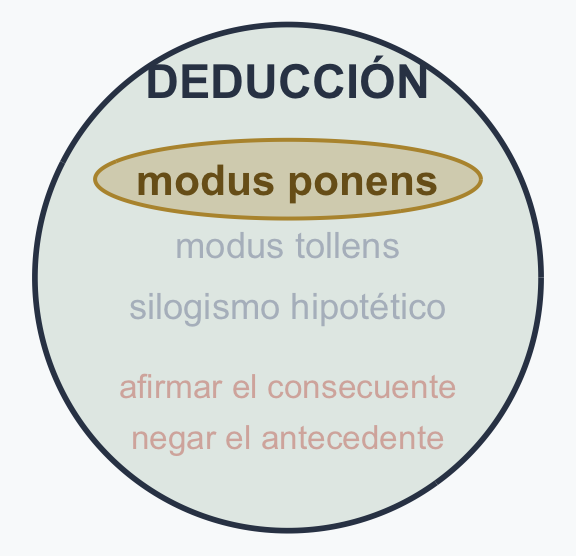

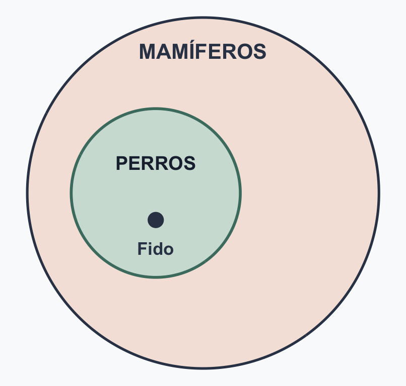

Figure 1

## Modus tollens

**P1:** Si algo es perro, entonces es mamífero.  
**P2:** Fido no es mamífero.  
**C:** Fido no es perro.

**modus tollens**

Shape: **Si P, entonces Q. No Q. entonces No P**

**Válido** — la lógica detrás de la *falsación*.

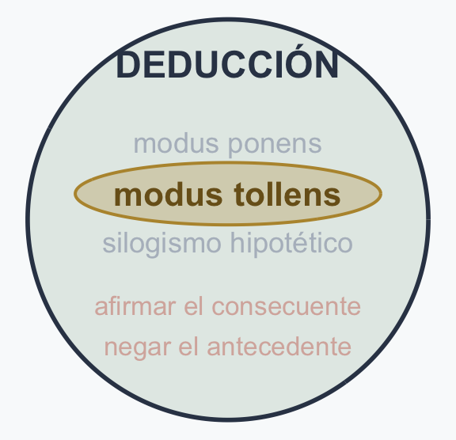

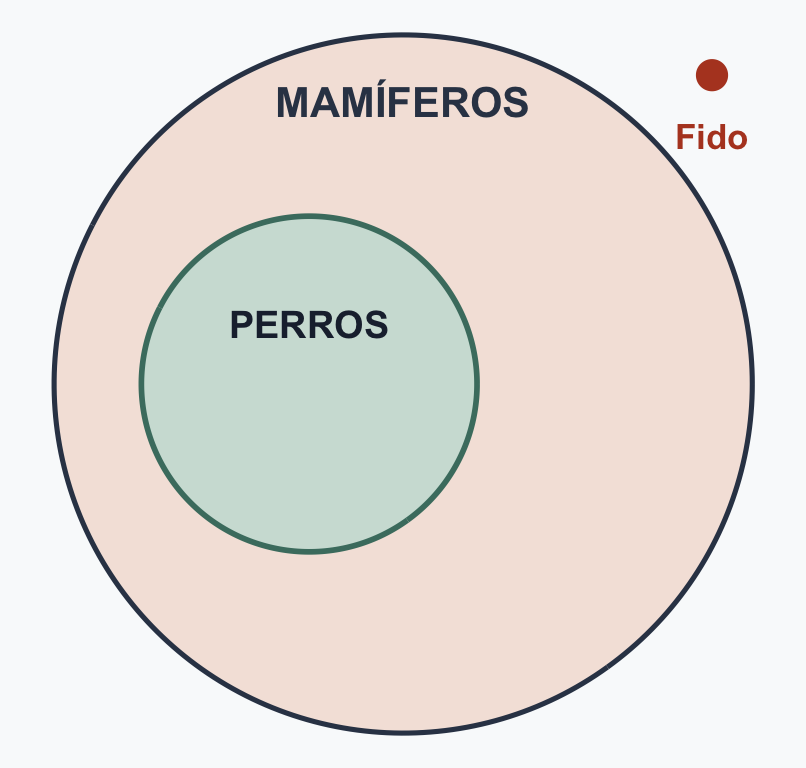

Figure 2

## Silogismo hipotético

**P1:** Si perro, entonces mamífero.  
**P2:** Si mamífero, entonces animal.  
**C:** Si perro, entonces animal.

**silogismo hipotético**

Shape: **Si P, entonces Q. Si Q, entonces R. entonces Si P, entonces R**

**Válido** — pero cada eslabón añadido es otra premisa que puede fallar.

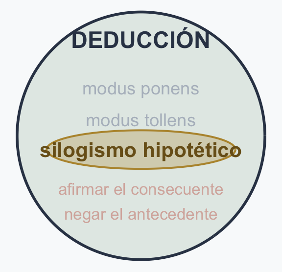

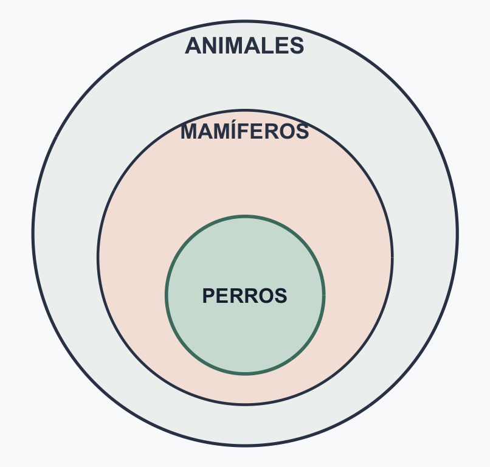

Figure 3

## Miren la conclusión

Dos reglas: *“Si llueve, la calle se moja.”* · *“Si la calle está mojada, está resbalosa.”*

|  | Agreguen esto | Concluyen |
| --- | --- | --- |
| **Modus ponens** | **Llovió.** | La calle **está mojada.** |
| **Silogismo hipotético** | *nada — solo la segunda regla* | **Si** llueve, la calle está resbalosa. |

¿Todavía trae un **“si”**? Silogismo hipotético. ¿Es una **afirmación seca**? Modus ponens.

## Afirmar el consecuente

**P1:** Si algo es perro, entonces es mamífero.  
**P2:** Fido es mamífero.  
**C:** Fido es perro.

Pero Fido podría ser un **gato** — ser perro es solo *una* forma de ser mamífero.

**afirmar el consecuente *(inválido)***

Shape: **Si P, entonces Q. Q. entonces P**

**Trampa** — lee la regla **al revés.**

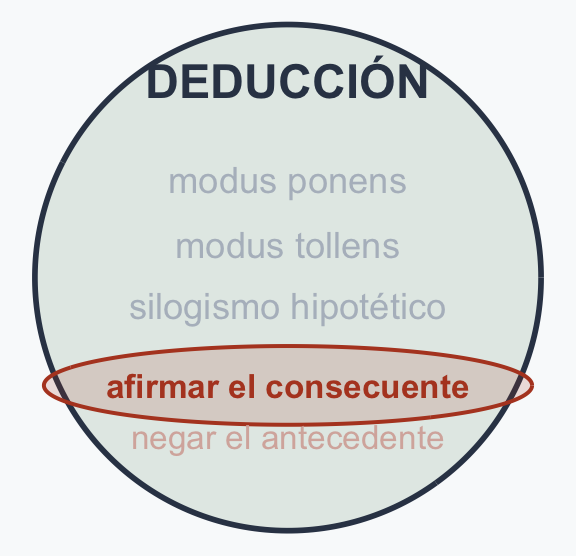

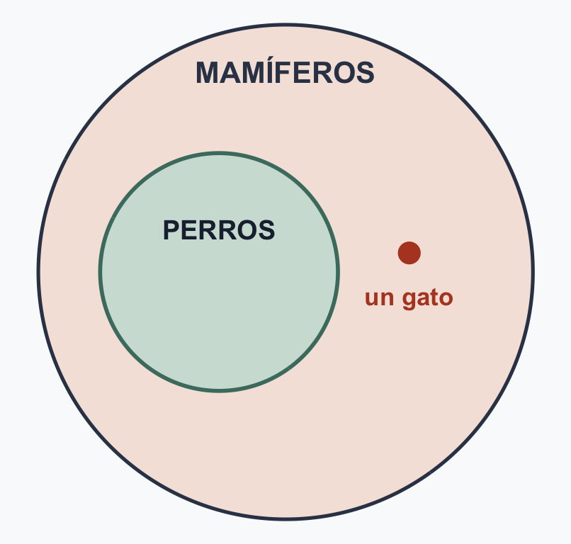

Figure 4

## Negar el antecedente

**P1:** Si algo es perro, entonces es mamífero.  
**P2:** Fido no es perro.  
**C:** Fido no es mamífero.

Pero Fido podría ser un **gato** — no es perro, y sigue siendo mamífero.

**negar el antecedente *(inválido)***

Shape: **Si P, entonces Q. No P. entonces No Q**

**Trampa** — olvida que Q puede darse **sin P.**

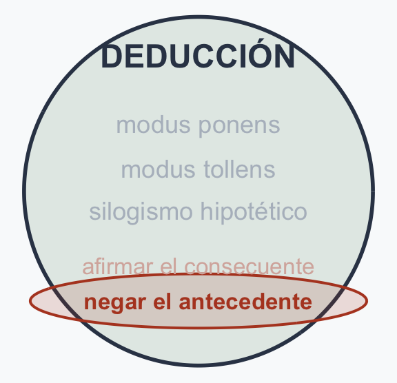

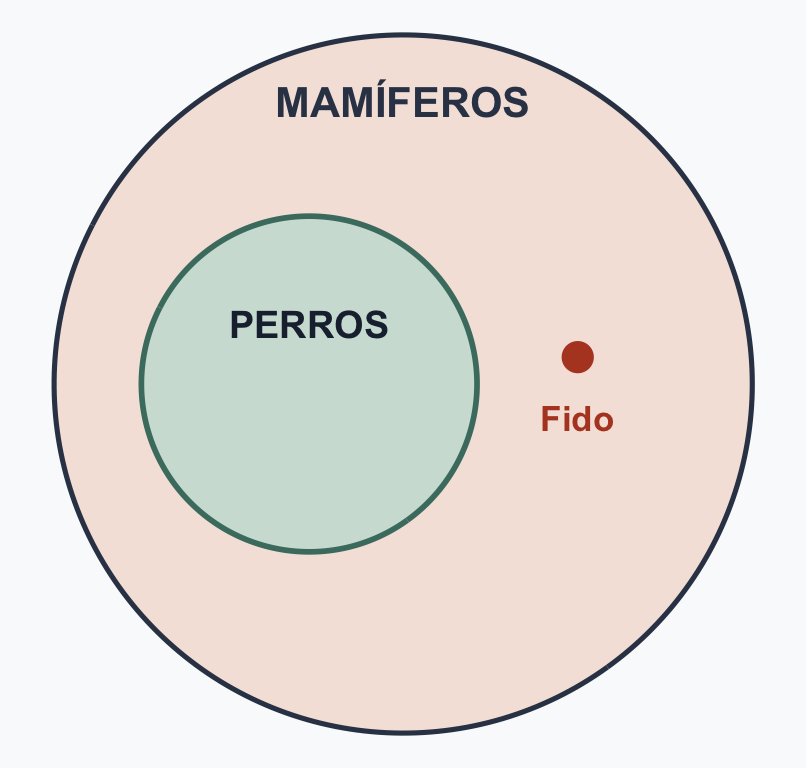

Figure 5

## Herramienta vs. trampa

Cada trampa **invierte** a su contraparte válida *(todas comparten la regla: **Si P, entonces Q**)*:

| Herramienta válida | Contraparte inválida | Dónde se descompone |
| --- | --- | --- |
| **Modus ponens** — *P, entonces Q* | **Afirmar el consecuente** — *Q, entonces P* | lee la regla **al revés** |
| **Modus tollens** — *No Q, entonces No P* | **Negar el antecedente** — *No P, entonces No Q* | olvida que Q puede darse **sin P** *(el gato)* |

Dos preguntas atrapan casi todos los errores: **(1)** ¿Voy en la *dirección* que dice el condicional? **(2)** ¿Era P la *única* ruta hacia Q, o solo *una*?

## Necesario vs. suficiente

> “Si es perro, entonces es mamífero.”
- **Perro es suficiente** para mamífero — ser perro garantiza ser mamífero.
- **Mamífero es necesario** para perro — sin mamífero, no hay perro.
- Las trampas salen de intercambiar los dos.

## Las cuatro familias

| Familia | Falacias |
| --- | --- |
| **Razonamiento defectuoso** | falsa causa · razonamiento circular |
| **Fuentes mal usadas** | ad hominem · apelación a la autoridad |
| **Afirmaciones distorsionadas** | *(Sesión 10 — no entra en este examen)* |
| **Apelaciones emocionales** | *(Sesión 10 — no entra en este examen)* |

Entran cuatro falacias. Las otras ocho vienen **después** del parcial.

## El diagnóstico en tres pasos

1. **Nombren** el movimiento.
2. **Citen** las palabras que lo cometen.
3. Digan qué **decidiría** la cuestión.

Nombrar no es refutar — el paso 3 es donde están los puntos.

## Las lecturas

- Sagan, C. (1995). El fino arte de detectar patrañas. En *El mundo y sus demonios: La ciencia como una luz en la oscuridad* (Cap. 12). Random House.
- Platón. (s.f.). *Eutifrón*.
- Hume, D. (1739). *Tratado de la naturaleza humana*, Libro III, Parte I, Sección I.
- Hume, D. (1748). *Investigación sobre el entendimiento humano*, Sección IV, “Dudas escépticas sobre las operaciones del entendimiento.”
- Vaughn, L., & MacDonald, C. (2019). *The power of critical thinking* (ed. canadiense). Oxford University Press. (Cap. 3, “Making sense of arguments”, pp. 58–106.)
- Kahneman, D. (2011). Los personajes de la historia. En *Pensar rápido, pensar despacio* (Cap. 1). Farrar, Straus and Giroux.
- Vaughn, L., & MacDonald, C. (2019). *The power of critical thinking* (ed. canadiense). Oxford University Press. (Cap. 5, “Fallacies and persuaders”, pp. 151–186.)

# Parte 2: Práctica

*Seis ejercicios. Las respuestas, en la diapositiva inmediatamente siguiente.*

## Ejercicio 1 — Etiqueten la afirmación

Marquen cada una **E**, **C** o **N**.

**1.** Nuestra Marina es más chica que en 1917.

**2.** “Fuerza” significa lo que un ejército puede hacer, no cuántas unidades tiene.

**3.** No deberíamos debilitar a la fuerza militar.

**4.** La participación electoral fue más baja este año que el pasado.

## Ejercicio 1 — Respuestas

|  |  | Por qué |
| --- | --- | --- |
| **1** | **E** | Cuenten los barcos. |
| **2** | **C** | Fija qué significa la palabra. |
| **3** | **N** | Una palabra de valor — y ningún dato lo zanja. |
| **4** | **E** | Consulten las cifras. |

## Parte A — En el examen

**A1.** Costa Rica abolió su ejército en 1948.  
**A2.** Por definición, un subsidio es un pago del gobierno a un productor.  
**A3.** El voto debería ser obligatorio.

Escriban solo esto:

> A1 – E A2 – C A3 – N

Una letra por reactivo. **Sin oraciones, sin justificar.**

## Ejercicio 2 — Familia y veredicto

¿Deductivo o inductivo? Luego: **sólido**, **cogente** o **ninguno**. *(Supongan que las premisas enunciadas son ciertas.)*

**1.** “Todos los cuadrados tienen cuatro lados. Esta figura es un cuadrado. Así que tiene cuatro lados.”

**2.** “Todos los perros son mamíferos. Este animal es mamífero. Así que es un perro.”

**3.** “Este paso de montaña ha cerrado por nieve todos los inviernos durante treinta años. Así que probablemente cierre este invierno también.”

**4.** “Dos de mis amigos se enfermaron después de comer ahí. Así que ese restaurante probablemente tiene mala higiene.”

## Ejercicio 2 — Respuestas

|  | Familia | Veredicto | Por qué |
| --- | --- | --- | --- |
| **1** | deductivo | **sólido** | “Cuadrado” obliga a “cuatro lados”. |
| **2** | deductivo | **ninguno** | Inválido — un gato también es mamífero. |
| **3** | inductivo | **cogente** | Treinta inviernos, el mismo paso, la misma causa. |
| **4** | inductivo | **ninguno** | Débil — dos casos, sin tasa base. |

Un enlace roto lo termina. Nada rescata a un argumento inválido.

## Parte B — En el examen

**B1.** “Todo tratado que ratifica el senado es vinculante. El senado ratificó este tratado. Así que este tratado es vinculante.”

Escriban solo esto:

> B1 – deductivo, sólido

**Dos cosas**: el tipo y luego el veredicto. Supongan que las premisas son ciertas.

## Ejercicio 3 — Nombren la forma

Nombren el patrón, luego digan **válido** o **trampa**.

**1.** “Si es perro, entonces es mamífero. Rex es perro. Entonces Rex es mamífero.”

**2.** “Si el video es falso, el detector lo marca. El detector lo marcó. Entonces el video es falso.”

**3.** “Si la vacuna causó el brote, los vacunados se habrían enfermado. No se enfermaron. Entonces no lo causó.”

**4.** “Si ella borró los archivos, es culpable. No los borró. Entonces no es culpable.”

**5.** “Si es perro, es mamífero. Si es mamífero, es animal. Entonces si es perro, es animal.”

## Ejercicio 3 — Respuestas

|  | Forma |  |
| --- | --- | --- |
| **1** | Modus ponens | **válido** |
| **2** | Afirmar el consecuente *(Trampa 1)* | **trampa** |
| **3** | Modus tollens | **válido** |
| **4** | Negar el antecedente *(Trampa 2)* | **trampa** |
| **5** | Silogismo hipotético | **válido** |

Las dos trampas leen la flecha **al revés** — o borran una ruta que nunca fue la única.

## Parte C — En el examen

**C1.** “Si el envío salió el lunes, llega el jueves. No llegó el jueves. Así que no salió el lunes.”

Escriban solo esto:

> C1 – modus tollens, válido

El nombre y luego **válido o trampa**. También se acepta *Herramienta 2*.

## Ejercicio 4 — Nombren la falacia

**Falsa causa · razonamiento circular · ad hominem · apelación a la autoridad**

**1.** “Brawndo tiene lo que las plantas necesitan — tiene electrolitos. Y los electrolitos son lo que las plantas necesitan.”

**2.** “No hay pruebas porque está encubierto, y sabemos que está encubierto porque no hay pruebas.”

**3.** “Las cifras del alcalde muestran que el toque de queda bajó la delincuencia. Pero el alcalde es un ratero — ignórenlas.”

**4.** “Más médicos fuman esta marca que cualquier otra, así que ha de ser segura.”

## Ejercicio 4 — Respuestas

|  |  | Por qué |
| --- | --- | --- |
| **1** | **razonamiento circular** | Cada vuelta renombra la afirmación. No llega nada nuevo. |
| **2** | **razonamiento circular** | Dos afirmaciones, cada una apoyada en la otra. |
| **3** | **ad hominem** | Ataca al alcalde, no a las cifras. Un ratero puede tener datos correctos. |
| **4** | **apelación a la autoridad** | La encuesta fue real — y la marca preferida no es un hallazgo de seguridad. |

Los círculos no tienen que repetir palabras — **el 1 y el 2 son el mismo movimiento.**

## Parte D — En el examen

**D1.** “Esta marca debe ser la mejor: la recomienda un futbolista famoso.”

Escriban solo esto:

> D1 – apelación a la autoridad

**Solo el nombre.** Sin cita y sin explicación — eso es trabajo de la Parte E.

## Ejercicio 5 — Apliquen los tres pasos

> “La delincuencia bajó después del toque de queda. El toque de queda funciona.”
- **Nombren** el movimiento.
- **Citen** las palabras.
- Digan qué lo **decidiría**.

## Ejercicio 5 — Respuestas

| Paso |  |
| --- | --- |
| **Nombre** | Falsa causa |
| **Cita** | “La delincuencia bajó **después** del toque de queda. El toque de queda funciona.” |
| **Decidir** | ¿Ya venía bajando antes? ¿Qué pasó en ciudades comparables sin toque de queda? |

“Después” no es “por causa de”. Descarten las rivales, o no han mostrado nada.

## Parte E — En el examen

> “La asistencia al museo subió 30% el año siguiente a la apertura del café. El café fue lo que atrajo a la gente.”

Escriban tres renglones separados:

> E(a) – falsa causa  
> E(b) – “El café fue lo que atrajo a la gente”  
> E(c) – Revisaría dos cosas: 1) si la asistencia ya venía subiendo antes de que abriera el café, y 2) si otros museos de la ciudad subieron lo mismo ese año.

## Ejercicio 6 — Reconstruyan

> “Los videojuegos violentos deberían restringirse para menores — los niños que los juegan se portan más agresivos en la escuela.”

Pónganlo en forma estándar. Encuentren la **premisa oculta.**

## Ejercicio 6 — Respuestas

| P1. | Los niños que juegan videojuegos violentos se portan más agresivos en la escuela. *(E)* |
| --- | --- |
| P2. | *(oculta)* Esa agresividad la causan los juegos, no es mera correlación. *(E)* |
| P3. | *(oculta)* Deberíamos restringir lo que vuelve más agresivos a los niños. *(N)* |
| C. | Los videojuegos violentos deberían restringirse para menores. |

La conclusión es un **debería.** Así que al menos una premisa tiene que ser un **debería.**

## Parte F — En el examen

> “Los puestos de comida en la calle deberían inspeccionarse como los restaurantes: al fin y al cabo, le sirven comida al público.”

Escriban el argumento y luego la etiqueta:

> P1. Los puestos de comida en la calle le sirven comida al público.  
> P2. Todo lo que le sirve comida al público debería inspeccionarse como un restaurante.  
> C. Los puestos de comida en la calle deberían inspeccionarse como los restaurantes.  
> Resp: N

P1 **está** en la oración. P2 es la que nadie dijo.

## Parte G — En el examen

**G1.** Vaughn y MacDonald, Cap. 5 **G2.** Hume, *Tratado*

(a) por qué los hechos solos nunca resuelven qué se debe hacer  
(b) un catálogo de las formas con nombre en que falla un argumento  
(c) cómo se desarrolló la lógica formal después de Aristóteles

Escriban solo esto:

> G1 – b G2 – a

Una letra por lectura. **Siempre sobra una opción**, para que la última respuesta no salga por descarte.

## Conclusión

- **Practiquen, no relean.** Rehagan los ejercicios con las respuestas tapadas.
- **Digan los cuatro pasos** en voz alta, en orden, de memoria. *familia · vínculo · premisas · veredicto*
- **Ensayen las cuatro falacias** — el nombre, y luego qué lo decidiría. *falsa causa · circular · ad hominem · apelación a la autoridad*
- **Un renglón por lectura** — de qué trataba, nada más.

## Encuesta

[figure not shown]